# Deng2014

Wancen Mu, Hirak Sarkar, Avi Srivastava, Kwangbom Choi, Rob Patro, Michael I. Love

08/25/2021

Abstract

Airpart identifies sets of genes displaying differential cell-type-specific allelic imbalance across cell types or states, utilizing single-cell allelic counts. It makes use of a generalized fused lasso with binomial observations of allelic counts to partition cell types by their allelic imbalance. Alternatively, a nonparametric method for partitioning cell types is offered. The package includes a number of visualizations and quality control functions for examining single cell allelic imbalance datasets.

# Load data

First, we load the preprocessed [Deng 2014](https://science.sciencemag.org/content/343/6167/193.long) data. It includes one maternal allelic counts(`cast`) and paternal allelic counts(`b6`) which was derived after removing some low quality cells indicated in the previous paper. `celltype` is a character vector of all cell types.

```r
suppressPackageStartupMessages(library(SingleCellExperiment))
load("../data/Deng.rda")
cell_meta_unique <- c("zy","early2cell","mid2cell","late2cell","4cell","8cell","16cell","earlyblast","midblast","lateblast")
order_of_development <- order(match(celltype,cell_meta_unique))
assay.list<-list(a1=cast[,order_of_development],a2=b6[,order_of_development])
coldata<-data.frame(x=factor(celltype[order_of_development],levels=cell_meta_unique))
sce<-SingleCellExperiment(assays=assay.list, colData=coldata)
```

# Create Ratio matrix

Here we add the pseudo count for gene clustering and visualization.

```r
sce <- preprocess(sce)
```

Take a look at highest expressed genes

```r
counts(sce)[order(rowSums(counts(sce)),decreasing = T)[1:10],sample(dim(sce)[2],5)]
```

```
##          zy1_expression.txt midblast_3-15 16cell_4-7 midblast_3-5
## Lrpap1                  169          3768       3843         5068
## Gpd1l                    87          1664       4058         1291
## Tcfcp2l1                481          3246       2507         4199
## Echdc2                   28          2319       2188         2597
## Psat1                     0           710       2868          687
## Eif3l                     1           680       2205         2778
## Brca2                  8375           463        229          583
## Rsl1d1                 2825           534       1558         1807
## Ppil1                     0          1717       1831         1799
## Nolc1                  1477          2555       2127         1919
##          earlyblast_3-8
## Lrpap1             2332
## Gpd1l               736
## Tcfcp2l1           3288
## Echdc2             2346
## Psat1              2390
## Eif3l              2788
## Brca2               165
## Rsl1d1             2401
## Ppil1              2586
## Nolc1               387
```

# Quality control step

### QC on cells

```r
cellQCmetrics<-cellQC(sce,mad_detected=4,mad_spikegenes = 5,spike = "Ercc")
cellQCmetrics
```

```
## DataFrame with 231 rows and 7 columns
##                             x       sum  detected spikePercent filter_sum
##                      <factor> <numeric> <numeric>    <numeric>  <logical>
## zy1_expression.txt zy           6.52523      9038    0.0385957       TRUE
## zy2_expression.txt zy           6.53900      9646    0.0464168       TRUE
## zy3_expression.txt zy           6.47349      9983    0.0438849       TRUE
## zy4_expression.txt zy           6.32996      9515    0.0335044       TRUE
## early2cell_0r-1    early2cell   6.14029      8708    0.0367182       TRUE
## ...                       ...       ...       ...          ...        ...
## lateblast_1-5       lateblast   5.94870      2920  0.000112537       TRUE
## lateblast_1-6       lateblast   5.41426      5777  0.025818385       TRUE
## lateblast_1-7       lateblast   6.03532      6338  0.065035760       TRUE
## lateblast_1-8       lateblast   6.13056      7279  0.040439801       TRUE
## lateblast_1-9       lateblast   5.98867      6982  0.058746683       TRUE
##                    filter_detected filter_spike
##                          <logical>    <logical>
## zy1_expression.txt            TRUE         TRUE
## zy2_expression.txt            TRUE         TRUE
## zy3_expression.txt            TRUE         TRUE
## zy4_expression.txt            TRUE         TRUE
## early2cell_0r-1               TRUE         TRUE
## ...                            ...          ...
## lateblast_1-5                 TRUE         TRUE
## lateblast_1-6                 TRUE         TRUE
## lateblast_1-7                 TRUE         TRUE
## lateblast_1-8                 TRUE         TRUE
## lateblast_1-9                 TRUE         TRUE
```

Now define cell filtering automatically or users can manually filter out based on `sum`,`detected` and `spikePercent`.

```r
keep_cell <- (
  cellQCmetrics$filter_sum & # sufficient features (genes)
  cellQCmetrics$filter_detected & # sufficient molecules counted
  cellQCmetrics$filter_spike  # sufficient features expressed compared to spike genes, high quality cells
)
table(keep_cell)
```

```
## keep_cell
## FALSE  TRUE
##     2   229
```

```r
sce<-sce[,keep_cell]
```

### QC on genes

Note that we require genes expressed in at least **25%** cells within each cell types.

```r
featureQCmetric<-featureQC(sce,spike = "Ercc",sd = 0.03)
keep_feature<-(featureQCmetric$filter_celltype &
                 featureQCmetric$filter_sd &
                 featureQCmetric$filter_spike)
table(keep_feature)
```

```
## keep_feature
## FALSE  TRUE
## 17383  4781
```

```r
sce<-sce[keep_feature,]
```

# Gene clustering

We provide two methods for gene clustering. Gaussian mixture modeling was used in this case. Hierarchical clustering is an alternative way for clustering.

### Exclude chromosome X genes

```r
load("../data/mm9_genome.rda")
gene_chrx<- unname(g$sym[which(seqnames(g)=="chrX")])
sce <- sce[-which(rownames(sce)%in%gene_chrx),]
```

### 1. Gaussian Mixture modeling

Gaussian mixture modeling is the default method for gene clustering. The scatter plot is shown based on top 2 PCs of the smoothed allelic ratio data. The argument `plot=FALSE` can be used to avoid showing the plot. We have found gene clusters more spread out, more extreme allelic imbalance they have.

```r
sce<-geneCluster(sce, G=c(8))
```

```
## model-based optimal number of clusters: 8
```

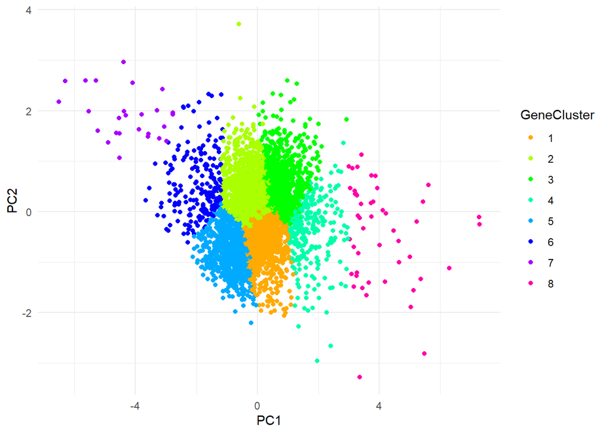

```r
metadata(sce)$geneCluster
```

```
## [1]  943 1444  922  257  827  212   26   48
```

### Simple summary table of alleic ratio

Quickly look at the weighted mean of allelic ratio for each gene cluster. Identify the interested gene cluster. Note that we recommend users only run `airpart` when the largest ordered allelic ratio difference > 0.05 for speed concerns. We find that the allelic ratio of most of the gene clusters in such cases (small absolute allelic ratio differences) won’t provide enough evidence to detect differential allelic imbalance.

Because we are modlling including zygote that mainly involves maternal effect, we find out all clusters exists differential alleic imbalance because weighted allelic ratio mean all really close to 0.

```r
summary<-summaryAllelicRatio(sce)
sapply(1:length(summary), function(i) {
  inst <- summary[[i]]
  inst_order <- inst[order(inst$weighted.mean), ]
  max(diff(inst_order$weighted.mean)) > 0.05
})
```

```
## [1] TRUE TRUE TRUE TRUE TRUE TRUE TRUE TRUE
```

Hence, we remove the zygote and early2cell cell types and redo the analysis to lower the maternal effect and try to find any meaningful gene sets.

```r
sce <- sce[,sce$x%in%cell_meta_unique[3:10]]
sce$x <- factor(sce$x,cell_meta_unique[3:10])
sce<-geneCluster(sce, G=seq(4,20,4))
```

```
## model-based optimal number of clusters: 16
```

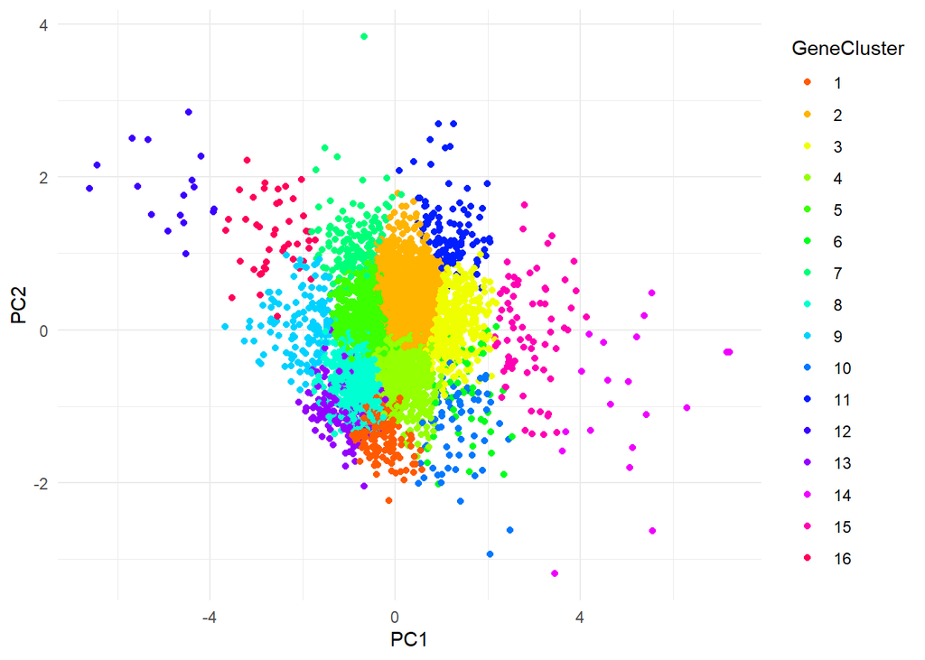

```r
metadata(sce)$geneCluster
```

```
##  [1]  154 1479  405  697  649   53  137  519  136   65  112   17  118   20   74
## [16]   44
```

```r
summary<-summaryAllelicRatio(sce)
sapply(1:length(summary), function(i) {
  inst <- summary[[i]]
  inst_order <- inst[order(inst$weighted.mean), ]
  max(diff(inst_order$weighted.mean)) > 0.05
})
```

```
##  [1]  TRUE FALSE  TRUE  TRUE  TRUE  TRUE FALSE  TRUE  TRUE  TRUE  TRUE  TRUE
## [13]  TRUE  TRUE  TRUE FALSE
```

Here we use gene cluster 10 as an example. Since it has higher dispersion, we will use nonparametric approach to partitioning the cell types.

### Modeling using non-paramateric method

*airpart* offers a method for partitioning cell types using non-parametric method because we find that when the allelic counts deviates strongly from a binomial (e.g. large over-dispersion, small values of `theta`). we have implemented wherein all pairs cell types are compared with Mann-Whitney-Wilcoxon rank sum tests. Cell types are merged based on their similarity of allelic ratios, accounting for excess variability on the ratio from low counts.

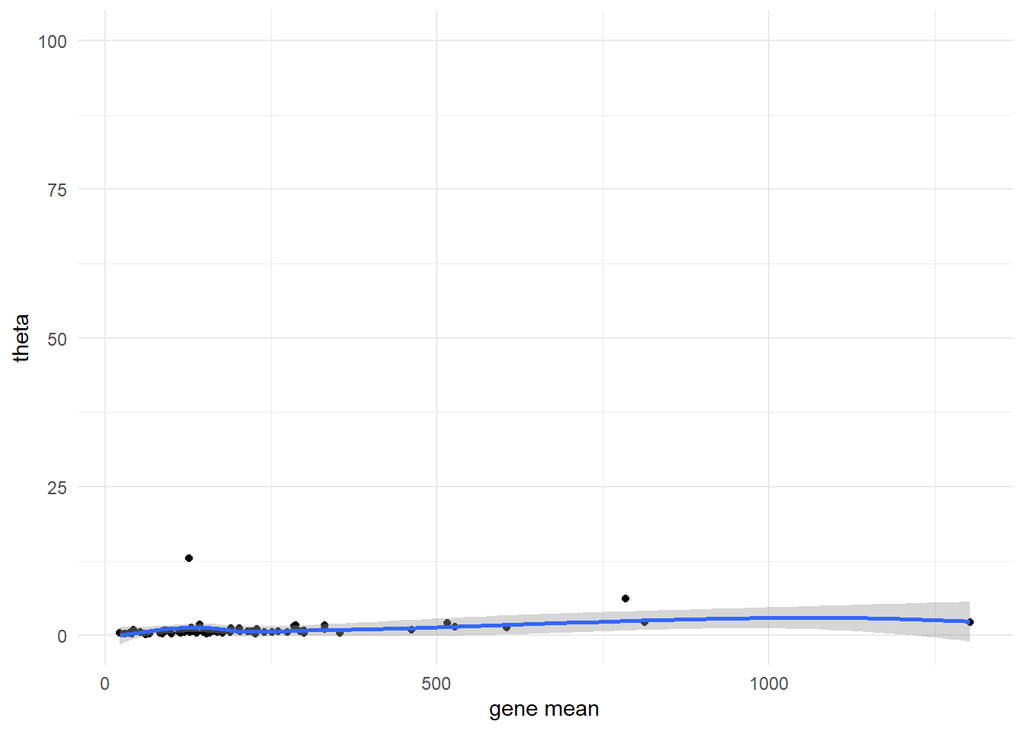

```r
estDisp(sce,genecluster = 10)
```

```r
sce_sub <- wilcoxExt(sce, genecluster = 10,threshold = 10^seq(from=-4,to=-2,by=0.2))
knitr::kable(metadata(sce_sub)$partition,row.names = F)
```

| part | x |
| --- | --- |
| 1 | mid2cell |
| 2 | late2cell |
| 3 | 4cell |
| 4 | 8cell |
| 4 | 16cell |
| 5 | earlyblast |
| 5 | midblast |
| 5 | lateblast |

### Heatmap to show the cell types partition:

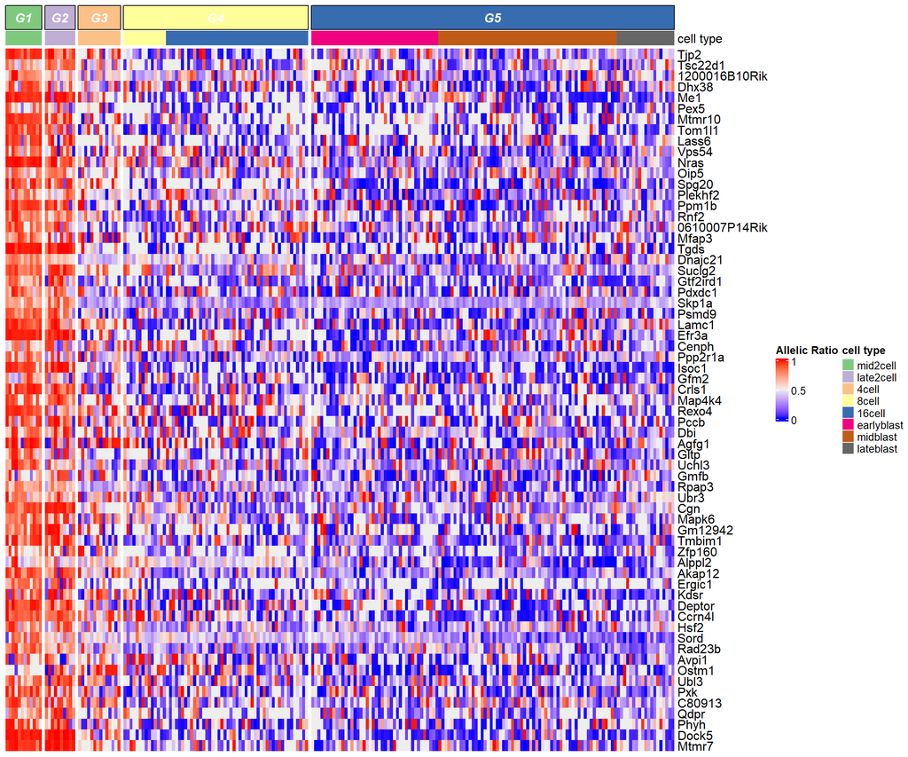

```r
# jpeg(file="C:/Users/wancen/OneDrive - University of North Carolina at Chapel Hill/Lab/GRA/plot/heatmap_Deng.jpeg",width = 10, height = 9,units = "in",res=450)
makeHeatmap(sce_sub,order_by_group = FALSE,show_row_names = T)
```

```r
# dev.off()
```

### Calculating allelic ratio estimate via hierarchical Bayesian modeling

```r
sce_sub <- allelicRatio(sce_sub)
```

### Violin plot to show posterior mean allelic ratios on the y-axis

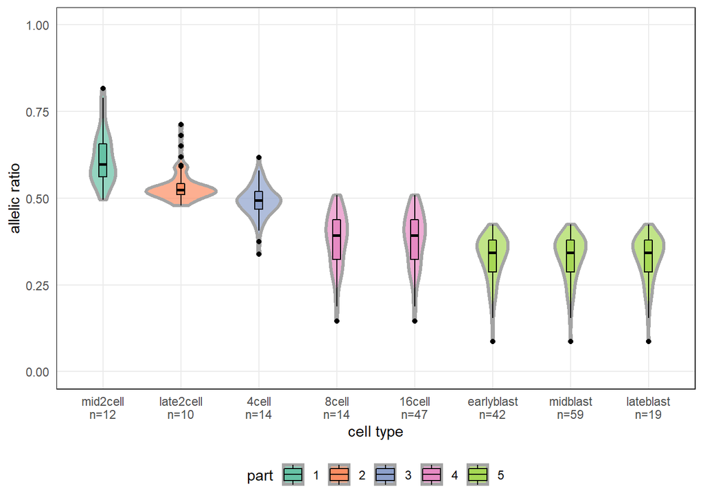

```r
makeViolin(sce_sub)
```

# GO term analysis

```r
suppressMessages(suppressWarnings(library(goseq)))
suppressMessages(suppressWarnings(library(kableExtra)))
i=10
feat<-which(rowData(sce)$cluster==i)
genes <- rep(0,nrow(sce))
names(genes) <- rownames(sce)
genes[feat] <- 1
table(genes)
```

genes 0 1 4614 65

```r
suppressMessages(pwf <- nullp(genes, "mm9", "geneSymbol"))
```

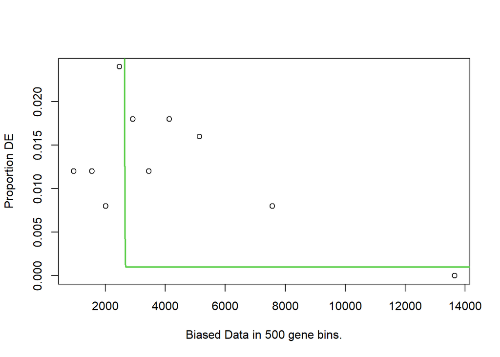

```r
suppressMessages(gores <- goseq(pwf, "mm9", "geneSymbol"))
p_adjust <- p.adjust(gores$over_represented_pvalue,method = "fdr")
gores$`p.adjust`<-p_adjust
head(gores[gores$ontology=="BP" & gores$numInCat>15,], 20) %>%
  kbl() %>%
  kable_paper("hover", full_width = F)
```

|  | category | over_represented_pvalue | under_represented_pvalue | numDEInCat | numInCat | term | ontology | p.adjust |
| --- | --- | --- | --- | --- | --- | --- | --- | --- |
| 8834 | GO:0048468 | 0.0000100 | 0.9999985 | 11 | 456 | cell development | BP | 0.0017099 |
| 928 | GO:0003008 | 0.0000560 | 0.9999918 | 9 | 233 | system process | BP | 0.0093604 |
| 4966 | GO:0030316 | 0.0000625 | 0.9999998 | 2 | 19 | osteoclast differentiation | BP | 0.0103269 |
| 4941 | GO:0030258 | 0.0001022 | 0.9999932 | 5 | 69 | lipid modification | BP | 0.0159767 |
| 9187 | GO:0050905 | 0.0001124 | 0.9999995 | 2 | 27 | neuromuscular process | BP | 0.0173896 |
| 543 | GO:0001885 | 0.0001466 | 1.0000000 | 1 | 17 | endothelial cell development | BP | 0.0215182 |
| 4888 | GO:0030154 | 0.0001619 | 0.9999598 | 14 | 812 | cell differentiation | BP | 0.0233387 |
| 5781 | GO:0032501 | 0.0001856 | 0.9999396 | 23 | 1358 | multicellular organismal process | BP | 0.0262363 |
| 4517 | GO:0019751 | 0.0001991 | 0.9999952 | 3 | 25 | polyol metabolic process | BP | 0.0268528 |
| 2413 | GO:0007044 | 0.0002319 | 0.9999984 | 2 | 32 | cell-substrate junction assembly | BP | 0.0307672 |
| 12563 | GO:0150115 | 0.0002323 | 0.9999984 | 2 | 34 | cell-substrate junction organization | BP | 0.0307672 |
| 9005 | GO:0048869 | 0.0004056 | 0.9998895 | 14 | 841 | cellular developmental process | BP | 0.0527614 |
| 432 | GO:0001667 | 0.0004421 | 0.9999720 | 4 | 95 | ameboidal-type cell migration | BP | 0.0570160 |
| 936 | GO:0003018 | 0.0004531 | 0.9999856 | 3 | 25 | vascular process in circulatory system | BP | 0.0579184 |
| 6314 | GO:0034330 | 0.0005050 | 0.9999665 | 4 | 155 | cell junction organization | BP | 0.0629112 |
| 9006 | GO:0048870 | 0.0005347 | 0.9999173 | 7 | 296 | cell motility | BP | 0.0651001 |
| 9529 | GO:0051674 | 0.0005347 | 0.9999173 | 7 | 296 | localization of cell | BP | 0.0651001 |
| 3960 | GO:0016311 | 0.0005358 | 0.9999476 | 5 | 116 | dephosphorylation | BP | 0.0651001 |
| 7824 | GO:0044282 | 0.0005419 | 0.9999322 | 6 | 85 | small molecule catabolic process | BP | 0.0653036 |
| 7074 | GO:0040011 | 0.0005578 | 0.9999131 | 7 | 313 | locomotion | BP | 0.0666643 |